# Exploring FGM in Kenya: The Power of Educated and Empowered Women

Exploring FGM in Kenya: The Power of Educated and Empowered Women Meshack Omagwa 2025-07-03

## Introduction

This report seeks to explore the prevalence and patterns of Female Genital Mutilation (FGM) among Kenyan women using 2014 Demographic and Health Survey (DHS) data. The analysis focuses on how socio-demographic factors—particularly education, wealth, region, and media access—shape experiences and perceptions of FGM.

By investigating both the occurrence of FGM and attitudes toward its continuation, this report highlights the role of education and empowerment in the movement to end FGM. The goal is to provide data-driven insights that can inform advocacy, policy, and community engagement.

## Data and Methodology

The analysis uses data from the Kenya Demographic and Health Survey (KDHS), focusing on women aged 15–49. Key variables include FGM status, education level, region, media access, and opinion on FGM continuation.

According to the [World Health Organization (WHO)](https://www.who.int/news-room/fact-sheets/detail/female-genital-mutilation), **Female Genital Mutilation (FGM)** is defined as “all procedures that involve partial or total removal of the external female genitalia, or other injury to the female genital organs for non-medical reasons.”

The practice has no health benefits and can cause severe harm, including hemorrhage, infection, childbirth complications, and even death. The [WHO](https://www.who.int/news-room/fact-sheets/detail/female-genital-mutilation) emphasizes that **FGM** is internationally recognized as a violation of the human rights of girls and women, infringing their rights to health, security, and physical integrity.

In Kenya, Female Genital Mutilation (FGM) continues to pose a serious public health and human rights challenge. According to the [2022 Kenya Demographic and Health Survey (KDHS)](https://dhsprogram.com/pubs/pdf/FR384/FR384.pdf), approximately **15% of women aged 15–49** have undergone FGM—a notable decline from previous decades, yet still affecting millions of women nationwide.

The practice shows **regional variation**, with some areas reporting significantly higher prevalence than others. These differences often reflect underlying cultural beliefs and traditional norms that influence attitudes toward the practice.

FGM is frequently justified as a **rite of passage**, a method of preserving chastity, or a prerequisite for marriage eligibility ([UNICEF](https://www.unicef.org/kenya/fgm-fact-sheet), 2020; [WHO](https://www.who.int/news-room/fact-sheets/detail/female-genital-mutilation), 2021). Despite legal measures, including the [Prohibition of FGM Act (2011)](https://www.kenyalaw.org/kl/fileadmin/pdfdownloads/Acts/ProhibitionofFemaleGenitalMutilationAct_No32of2011.pdf), enforcement challenges persist—particularly in rural areas where the practice is deeply rooted.

A growing concern is the **medicalization of FGM**, where the procedure is carried out by health professionals in clinical settings. Although perceived as safer, medicalization does not eliminate the long-term physical and psychological harm associated with the practice ([WHO](https://www.who.int/news-room/fact-sheets/detail/female-genital-mutilation), 2022).

FGM in Kenya remains a serious violation of girls’ and women’s rights, demanding continued efforts in **education, law enforcement, and community-level awareness** to bring lasting change.

This report seeks to:

1. **Describe the prevalence of Female Genital Mutilation (FGM)** among Kenyan women aged 15–49 using the 2014 Kenya Demographic and Health Survey (KDHS).
2. **Explore how women’s empowerment characteristics—such as education level, employment status, wealth index and decision-making autonomy—relate to the likelihood of having undergone FGM.**
3. **Identify regional and demographic patterns** in FGM prevalence across Kenya.
4. **Communicate findings using clear visualizations and summaries** that are accessible to both technical and non-technical audiences.

## Demographic and Health Survey (DHS) data

In this study we will use demographic and Health Surveys (DHS) data which are a series of standardized surveys conducted periodically in developing countries that collect data on various aspects of population, health, and nutrition.

## Kenya Women’s Individual Recode, 2014

Several DHS datasets (called recodes) are made available from each survey. The *individual recode (IR)* dataset contains individual-level data on women aged 15 to 49 in the surveyed households. We will be using a women’s IR dataset for this analysis.

We will be looking at women’s individual recode (IR) data from **Kenya(2014)**. Key findings from this data can be found in this [report](https://drive.google.com/drive/folders/1J0gw4qpfbB8bYFbXx8QcsQEWgJSVwp_P).

FGM Kenya Data Preview

| respondent's current age | age in 5-year groups | region | type of place of residence | highest educational level | religion | literacy | frequency of reading newspaper or magazine | frequency of listening to radio | frequency of watching television | wealth index | respondent currently working | ever heard of female circumcision | respondent circumcised | number of daughters circumcised | female circumcision: continue or be stopped |
| --- | --- | --- | --- | --- | --- | --- | --- | --- | --- | --- | --- | --- | --- | --- | --- |
| 27 | 3 | 9 | 1 | 2 | 2 | 2 | 0 | 2 | 2 | 4 | 1 | 1 | 0 | 0 | 2 |
| 16 | 1 | 9 | 1 | 2 | 2 | 2 | 0 | 2 | 2 | 5 | NA | NA | NA | NA | NA |
| 25 | 3 | 9 | 1 | 1 | 2 | 2 | 0 | 2 | 2 | 4 | 1 | 1 | 0 | 0 | 2 |
| 23 | 2 | 9 | 1 | 2 | 2 | 2 | 1 | 2 | 2 | 4 | NA | NA | NA | NA | NA |
| 23 | 2 | 9 | 1 | 2 | 2 | 2 | 1 | 2 | 2 | 4 | NA | NA | NA | NA | NA |
| 26 | 3 | 9 | 1 | 2 | 2 | 2 | 0 | 2 | 2 | 4 | 1 | 1 | 0 | 0 | 2 |

## Prevalence of FGM among Women aged 15-49 years

### Table 1: Prevalence of FGM Among Women Aged 15–49 Years

| Respondent Circumcised | Count | Percentage (%) |
| --- | --- | --- |
| Missing | 16790 | 54 |
| No | 9912 | 31.9 |
| Yes | 4377 | 14.1 |

Table 1 presents the distribution of Female Genital Mutilation (FGM) status among women aged 15–49 in the dataset. Among the respondents, **14.1% reported having undergone FGM**, while **31.9% reported not undergoing the procedure**. A significant proportion (**54.0%**) of responses were either missing or not recorded.

The high rate of missing values highlights potential limitations in data completeness or the unwillingness of respondents to disclose their FGM status. As such, further analysis will focus on the available valid responses. To better understand the context of FGM in Kenya, the report will also explore **prevalence by region, age groups** and **educational level**, highlighting geographic and socio-demographic disparities.

### FGM Prevalence by Age-group

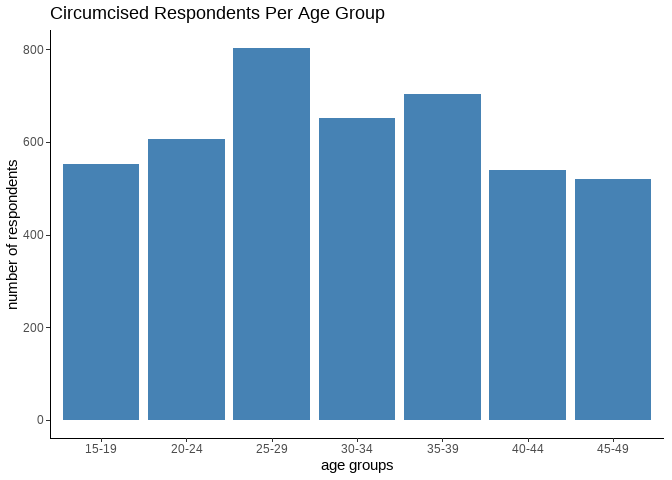

## FGM Prevalence by Education Level and region

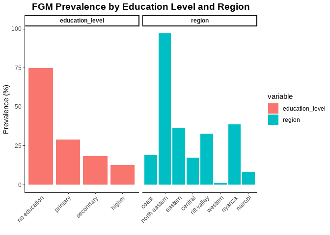

Figure 2: FGM prevalence by education level and region among women aged 15–49

These results highlight stark educational and regional disparities, indicating that both factors are strongly associated with FGM practices in Kenya.

### FGM prevalence by wealth index and employment status

[figure not shown]

Figure 3: FGM prevalence by wealth index and employment status

## Fgm awareness

Due to the high number of women who have undergone FGM, it is important to assess their level of awareness about the practice. Understanding awareness patterns can provide insight into the potential impact of advocacy, education, and exposure to information.

To explore this, a new variable was created to categorize respondents based on whether they had ever heard of FGM. A pie chart plot was then used to visualize the relationship awareness, with percentage representing the proportion of women in each category.

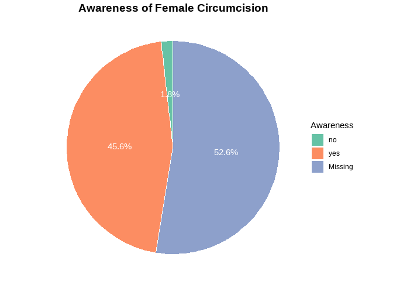

Figure 4: Distribution of FGM Awareness Among Women Aged 15–49

Over 45% of respondents have heard of female circumcision.  
However, a majority (around 52%) either did not respond or their awareness status is unknown (Missing).

## Attitudes Toward FGM: Should It Continue or Stop?

Beyond awareness and prevalence, it is important to examine societal attitudes about whether FGM should be abandoned or sustained. The dataset includes a variable capturing whether respondents believe that female circumcision should “continue” or “be stopped.”

Understanding these attitudes—especially in relation to women’s education levels—can reveal how empowerment influences opposition to harmful traditional practices.

The chart below shows the proportion of women who support stopping FGM, grouped by their highest education level.

## Opinions on FGM by Education Level

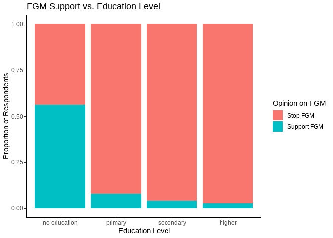

Figure 5: Opinions on whether FGM should stop, by education level

As shown in the chart, opposition to FGM is strongly associated with higher education levels. Among women with no education, support for stopping FGM is substantially lower than among those with secondary or higher education. This reinforces the idea that educational attainment empowers women with knowledge and agency to challenge harmful practices.

These findings underscore the critical role of education in shaping not just personal outcomes, but also social attitudes.

## Media Exposure and Awareness of FGM

Media can be a powerful tool for shaping health knowledge and social norms. This section examines how exposure to various media sources—newspapers, radio, and television—relates to awareness of female circumcision.

To do this, we transform the dataset into a long format where each row represents a woman’s exposure to one type of media. We then calculate and visualize the proportion of women who have heard of FGM, by frequency of media use.

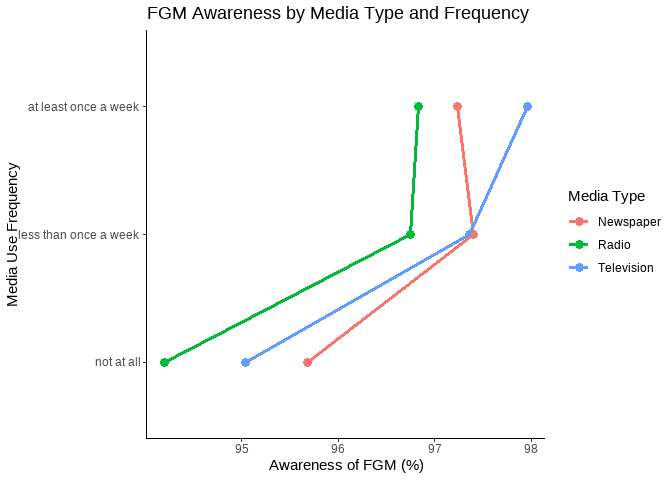

Figure 6: FGM awareness by media use frequency and type

From the plot above, awareness is high across the board Even women with no media exposure have relatively high FGM awareness (~94–95%).

Television shows the strongest awareness boost Women who watch TV at least once a week reach the highest awareness levels (~98%). This suggests TV may be especially effective in spreading anti-FGM messages.

## Table: Opinions on FGM by Region

The table below shows how support for continuing or stopping FGM varies by region. We present the proportion of women in each region who either support the continuation of FGM or believe it should be stopped.

This breakdown reveals regional differences in attitudes toward the practice. For instance, regions with higher FGM prevalence often have more support for its continuation, while urban and coastal areas show stronger opposition. These findings can guide region-specific awareness and intervention efforts.

### Opinions on FGM by Region Among Women Aged 15–49 Years

### Table 2: Regional Opinions on the Continuation of Female Genital Mutilation (FGM)

| Region | Stop FGM (%) | Support FGM (%) | No Opinion (%) |
| --- | --- | --- | --- |
| coast | 90.3 | 8.2 | 1.5 |
| north eastern | 10.4 | 88.7 | 0.9 |
| eastern | 83.9 | 15.5 | 0.7 |
| central | 97.0 | 2.4 | 0.6 |
| rift valley | 90.9 | 7.5 | 1.6 |
| western | 97.0 | 2.1 | 1.0 |
| nyanza | 88.4 | 9.0 | 2.6 |
| nairobi | 97.1 | 2.0 | 0.9 |

Source: Kenya DHS 2014

This table presents the percentage of women in each region who believe that FGM should either continue, be stopped, or expressed no opinion. The data reveals stark contrasts: for example, nearly 89% of respondents in North Eastern support the continuation of FGM, while support is minimal in regions like Central, Nairobi and Western, where more than 95% believe it should be stopped. These differences emphasize the role of localized cultural norms and the need for targeted awareness campaigns.

## FGM Prevalence by Religion: An Interactive View

While previous sections have examined FGM prevalence by education, age, and region, one important dimension not yet explored is religion. Religious beliefs and cultural norms often influence attitudes and practices surrounding Female Genital Mutilation (FGM).

The interactive widget below displays the distribution of FGM status by religious affiliation. It allows us to explore how the proportion of women who have undergone FGM differs across various religious groups in Kenya. This view adds a cultural layer to the analysis and can inform context-sensitive advocacy and policy interventions.

### FGM Prevalence by Religion

[interactive chart not shown]

Figure 7: FGM prevalence by religion

This visualization highlights significant differences in FGM prevalence across religious groups. Among women who identified as Muslim, FGM prevalence is notably high, exceeding 68%, whereas among Roman Catholics and Protestant/Other Christians, it is much lower (below 30%). The “Other” and “No Religion” categories show intermediate levels of prevalence, though sample sizes in these groups are relatively small.

These differences suggest that religious beliefs may influence cultural attitudes and practices related to FGM. This reinforces the importance of culturally sensitive, community-specific approaches when designing interventions to eliminate FGM.

## Literacy and Attitudes Toward FGM

Literacy is a key indicator of empowerment and access to information. In the context of Female Genital Mutilation (FGM), the ability to read may influence how individuals understand the risks, legality, and human rights implications of the practice.

This section explores how women’s reading ability relates to their opinions on whether FGM should be continued or stopped. By comparing literacy levels with responses on the continuation of FGM, we aim to examine whether basic literacy is associated with progressive views toward ending the practice.

Understanding this relationship is critical, as it may offer evidence for the role of education — even at the most fundamental level — in shifting cultural norms and supporting anti-FGM advocacy.

### Opinion on FGM Continuation by Literacy Level

[interactive chart not shown]

Figure 8: FGM Opinion by literacy level

This interactive chart illustrates the relationship between women’s literacy levels and their opinions on whether Female Genital Mutilation (FGM) should be continued or stopped. The majority of respondents across all literacy groups support ending FGM, especially those who can read whole or partial sentences. However, notable nuances emerge among the less literate subgroups and those with limited communication access.

Specifically:

Among women who cannot read at all, 2% responded “depends” and 0.5% said “don’t know”, indicating some uncertainty or lack of clarity around FGM.

Those able to read only parts of a sentence showed 1.7% “depends” and 0.2% “don’t know” — slightly more decisive than the illiterate group but still showing hesitation.

Among the fully literate group (able to read whole sentence), only 0.7% said “depends” and 0.2% “don’t know”, suggesting higher confidence in their stance — likely due to better access to information and education.

Interestingly, women with no card with required language recorded 0% in both categories, thus suporting that FGM should be stopped fully.

Women who are blind or visually impaired exclusively responded “depends” (2.8%), with no one choosing “don’t know”, suggesting a unique nuance in how information or context might shape their opinion.

These small proportions, though numerically minor, are meaningful. They highlight how reading ability and access to communication not only affect awareness but also the degree of certainty with which women express their views on FGM. Uncertainty (via “depends” or “don’t know”) is most prevalent among those with limited literacy or accessibility challenges, reinforcing the importance of inclusive education and tailored communication strategies in anti-FGM interventions.

### Final Insight: Which Factor Most Influences Support for Ending FGM?

Among the different variables explored — education, region, religion, literacy, and media — education emerges as the most consistent and powerful factor associated with opposition to FGM.

Women with higher levels of education overwhelmingly support stopping FGM, and they also demonstrate greater awareness and lower prevalence. Similarly, literacy is also strongly associated with anti-FGM views, but its effect is slightly less pronounced than formal education.

While religious affiliation and regional culture still matter — as shown by high support for FGM in certain regions or faith groups — these factors are less predictive across the entire population.

Therefore, investing in **girls’ education** not only reduces FGM risk but also shifts cultural attitudes, making it the most promising lever for long-term change.

## Conclusion

This report explored the prevalence and perceptions of Female Genital Mutilation (FGM) in Kenya, with a particular focus on how women’s education, literacy, media exposure, religion, and regional background shape both the likelihood of undergoing FGM and attitudes toward its continuation.

The findings reveal strong regional and cultural patterns — with North Eastern Kenya showing the highest FGM prevalence and strongest support for continuation. However, across all dimensions, **education** emerges as the most powerful influence. Women with higher levels of education and literacy are significantly more likely to oppose FGM, highlighting the importance of information, empowerment, and awareness in shaping attitudes.

Media access, though somewhat influential, appears less predictive than formal education. Similarly, religious affiliation and wealth status explain some variation, but their effects are less consistent. The evidence underscores that **empowering women through education** is one of the most effective strategies for reducing FGM and promoting cultural change.

Targeted interventions should therefore prioritize education — especially in high-prevalence regions — alongside culturally sensitive outreach that involves communities, religious leaders, and media platforms.

## Limitations

While this analysis provides important insights, several limitations should be noted:

1. **Missing Data:** A large proportion of records lack responses on key variables such as circumcision status, literacy, or opinions about FGM. These missing values may bias results, especially in subgroups with smaller sample sizes.
2. **Cross-Sectional Design:** The data is cross-sectional, capturing a single point in time. As such, we cannot infer causality — for example, whether education reduces FGM, or whether other factors influence both.
3. **Unmeasured Confounders:** Important factors such as family pressure, ethnicity, or exposure to anti-FGM campaigns were not available in the dataset but may influence both behavior and beliefs.
4. **Small Subgroups:** Some groups (e.g., visually impaired women or those with no language card) were very small, making it difficult to draw robust conclusions about their patterns.

Despite these limitations, the findings remain valuable for guiding targeted education and advocacy strategies aimed at eradicating FGM in Kenya.

## Policy Recommendations and Call to Action

To accelerate the eradication of Female Genital Mutilation (FGM) in Kenya, the following actions are recommended:

1. **Invest in Girls’ Education:** Expand access to quality education, especially in rural and high-prevalence regions like North Eastern Kenya. Education is the most consistent factor associated with opposition to FGM and should be central to anti-FGM policy.
2. **Integrate Literacy Programs into FGM Outreach:** For women who are out of school or in older age brackets, targeted adult literacy programs can empower them to make informed health decisions and challenge harmful cultural norms.
3. **Culturally Tailored Communication:** Design region-specific interventions that involve local leaders, religious institutions, and community elders — particularly in communities where FGM remains widely supported.
4. **Expand Media Access:** Support local radio, TV, and print campaigns in local languages that raise awareness about the risks and legal status of FGM. Media is an effective tool for shifting public opinion, especially among less formally educated populations.

Eradicating FGM requires a long-term, multisectoral approach — combining education, health, cultural engagement, and legal enforcement. With the right investments, Kenya can make meaningful progress toward protecting the rights and health of girls and women across all regions.